```r
options(jupyter.plot_mimetypes = c("text/plain", "image/png" )) # to ensure better graphs?
```

# Separability measures

For a cloud with tokens from all types

```r
library(semvar); library(RcppCNPy); library(rjson); library(repr)
```

Function to read the original distance matrices (before multidimensional scaling)

```r
get_tokvecs <- function(input_directory, filename){
  input_file = paste0(input_directory, filename)
  temp <- unzip(input_file, unzip="internal")
  tokvecs <- npyLoad(temp[2])
  metadata <- fromJSON(file=temp[1])
  dimid2item <- names(metadata$`dim-freq-dict`)
  dimnames(tokvecs) <- list(dimid2item, dimid2item)
  file.remove(temp[1], temp[2])
  return(tokvecs)
}
```

Loading variables for classification

```r
semcor = read.delim('../semcor.data.csv')
```

```r
get_d <- function(tokvecs){
  d.rows <- data.frame(factor(rownames(tokvecs)))
  colnames(d.rows)<-'id'
  d <- merge.data.frame(d.rows, semcor, by='id')
  return(droplevels(d))
}
```

Creating a dataframe with filenames and parameters, to select the correct filenames by selecting the parameters of the cloud.

```r
tokvecs_dir = "/home/mariana/Python3wf/output/token_matrices/COHAweight/"
nomds_files = data.frame(factor(dir(tokvecs_dir)))
colnames(nomds_files)='files'
```

```r
pattern = '^COHA.([a-z_\\.]+).socc(10k|6k).(nona)?.?min(\\d(_5)?).ttmx.dist.pac'
nomds_files$subset = gsub(pattern, '\\1', nomds_files$files)
nomds_files$socc = gsub(pattern, '\\2', nomds_files$files)
nomds_files$subsubset = gsub(pattern,'\\3', nomds_files$files)
nomds_files$threshold = gsub(pattern, '\\4', nomds_files$files)
nomds_files[nomds_files$subsubset != 'nona', 'subsubset']<-'all'
head(nomds_files)
```

| files | subset | socc | subsubset | threshold |
| --- | --- | --- | --- | --- |
| COHA.church.socc10k.min0.ttmx.dist.pac | church | 10k | all | 0 |
| COHA.church.socc10k.min1.ttmx.dist.pac | church | 10k | all | 1 |
| COHA.church.socc10k.min2_5.ttmx.dist.pac | church | 10k | all | 2_5 |
| COHA.church.socc10k.min2.ttmx.dist.pac | church | 10k | all | 2 |
| COHA.church.socc10k.nona.min0.ttmx.dist.pac | church | 10k | nona | 0 |
| COHA.church.socc10k.nona.min1.ttmx.dist.pac | church | 10k | nona | 1 |

Doing the same for clouds after MDS

```r
clouds_dir = "/home/mariana/delhikiev.github.io/COHAweight/"
mds_files = data.frame(factor(dir(clouds_dir, pattern='.+tsv')))
colnames(mds_files)='files'
```

```r
pattern = '^COHA.([a-z_\\.]+).socc(10k|6k).(nona)?.?min(\\d(_5)?).tsv'
mds_files$subset = gsub(pattern, '\\1', mds_files$files)
mds_files$socc = gsub(pattern, '\\2', mds_files$files)
mds_files$subsubset = gsub(pattern,'\\3', mds_files$files)
mds_files$threshold = gsub(pattern, '\\4', mds_files$files)
mds_files[mds_files$subsubset != 'nona', 'subsubset']<-'all'
head(mds_files)
```

| files | subset | socc | subsubset | threshold |
| --- | --- | --- | --- | --- |
| COHA.church.socc10k.min0.tsv | church | 10k | all | 0 |
| COHA.church.socc10k.min1.tsv | church | 10k | all | 1 |
| COHA.church.socc10k.min2_5.tsv | church | 10k | all | 2_5 |
| COHA.church.socc10k.min2.tsv | church | 10k | all | 2 |
| COHA.church.socc10k.nona.min0.tsv | church | 10k | nona | 0 |
| COHA.church.socc10k.nona.min1.tsv | church | 10k | nona | 1 |

Selecting parameters

```r
subset = 'sample'
nona = 'all'
threshold = '0'
```

```r
tokvecs6_fn = as.character(nomds_files[nomds_files$subset == subset & nomds_files$socc == '6k' & nomds_files$threshold == threshold & nomds_files$subsubset == nona, 'files'])
tokvecs10_fn = as.character(nomds_files[nomds_files$subset == subset & nomds_files$socc == '10k' & nomds_files$threshold == threshold & nomds_files$subsubset == nona, 'files'])
```

```r
cloud6_fn = as.character(mds_files[mds_files$subset == subset & mds_files$socc == '6k' & mds_files$threshold == threshold & mds_files$subsubset == nona, 'files'])
cloud10_fn = as.character(mds_files[mds_files$subset == subset & mds_files$socc == '10k' & mds_files$threshold == threshold & mds_files$subsubset == nona, 'files'])
```

Loading the files and getting dataframes.

- *tokvecs* are the distance matrices before MDS.
- *d* are dataframes with the categorial data for the tokens in the distance matrices.
- *c* are the clouds after MDS: these dataframes include the coordinates for the clouds and categorial data.
- *coord* are the columns with the coordinates of the clouds from the *c* dataframes.
- *dist* are the distance matrices built from *coord*.

The order of the tokens is the same in all cases: the *c* dataframes were originally generated from the *tokvecs* files and the *d* dataframes were created with *merge.data.frame*, prioritizing the order of *tokvecs* over the *semcor.data.csv* dataframe.

```r
tokvecs6 <-get_tokvecs(tokvecs_dir, tokvecs6_fn)
tokvecs10 <-get_tokvecs(tokvecs_dir, tokvecs10_fn)
```

```r
d6 <- get_d(tokvecs6)
d10 <- get_d(tokvecs10)
```

```r
c6 <- read.delim(paste0(clouds_dir, cloud6_fn))
c10 <- read.delim(paste0(clouds_dir, cloud10_fn))
coord6 <- c6[,c('model.x', 'model.y')]
coord10 <- c10[,c('model.x', 'model.y')]
dist6<-dist(coord6)
dist10 <-dist(coord10)
```

## Distance Ratio

General measure

```r
dr_tokvecs <- function(clusterclass){
    semvar6<-clusterqualDR(tokvecs6, d6[,clusterclass])
    semvar10<-clusterqualDR(tokvecs10, d10[,clusterclass])
    make_col <- function(semvardf, df_name){
        freqs <- as.vector(semvardf$classfreqs)
        n <- c(sum(freqs), length(freqs), freqs)
        q <- round(c(semvardf$globqual, semvardf$meanclassqual, semvardf$classqual),3)
        q2 <- round(c(semvardf$globqual2, semvardf$meanclassqual2, semvardf$classqual2),3)
        d<-cbind(n, q, q2)
        row.names(d)<-c('global separability', 'mean class separability', names(semvardf$classqual))
        colnames(d)<-c(paste0(df_name, '_n'), paste0(df_name, '_q'), paste0(df_name, "_q'"))
        return(d)
    }
    print(paste0('Distance ratio based separability, based on ', clusterclass))
    print(cbind(make_col(semvar6, '6k'), make_col(semvar10, '10k')))
    options(repr.plot.width=5, repr.plot.height=5)
    plot(semvar6, coord6)
    plot(semvar10, coord10)
    }
```

```r
dr_clouds <- function(clusterclass){
    semvar6<-clusterqualDR(dist6, c6[,clusterclass])
    semvar10<-clusterqualDR(dist10, c10[,clusterclass])
    make_col <- function(semvardf, df_name){
        freqs <- as.vector(semvardf$classfreqs)
        n <- c(sum(freqs), length(freqs), freqs)
        q <- round(c(semvardf$globqual, semvardf$meanclassqual, semvardf$classqual),3)
        q2 <- round(c(semvardf$globqual2, semvardf$meanclassqual2, semvardf$classqual2),3)
        d<-cbind(n, q, q2)
        row.names(d)<-c('global separability', 'mean class separability', names(semvardf$classqual))
        colnames(d)<-c(paste0(df_name, '_n'), paste0(df_name, '_q'), paste0(df_name, "_q'"))
        return(d)
    }
    print(paste0('Distance ratio based separability, based on ', clusterclass))
    print(cbind(make_col(semvar6, '6k'), make_col(semvar10, '10k')))
    options(repr.plot.width=5, repr.plot.height=5)
    plot(semvar6, coord6)
    plot(semvar10, coord10)
    }
```

```
                        6k_n  6k_q 6k_q' 10k_n 10k_q 10k_q'
global separability      499 1.028 1.022   499 1.033  1.027
mean class separability    3 1.037 1.026     3 1.026  1.025
church                    95 1.049 1.030    93 1.007  1.014
country                  115 1.051 1.043   114 1.028  1.020
state                    289 1.012 1.006   292 1.043  1.043
```

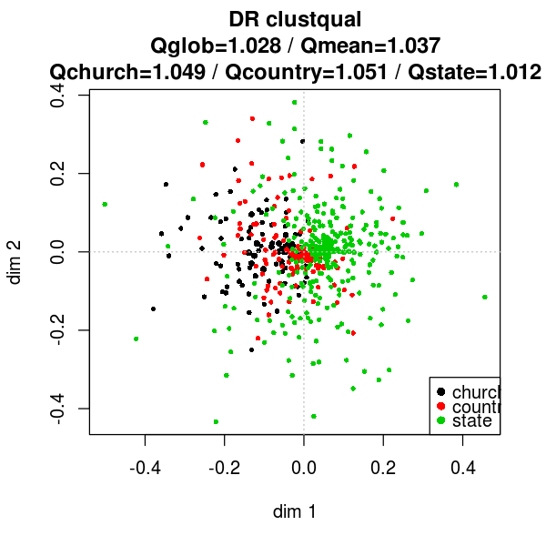

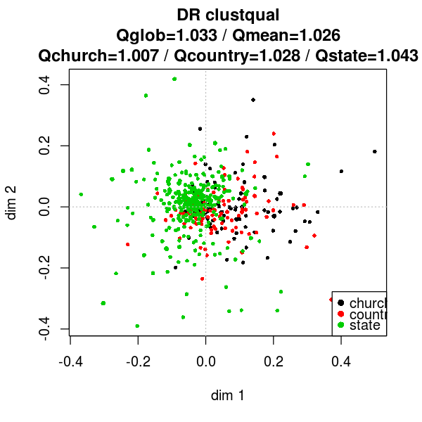

```r
dr_tokvecs('lemma')
```

```
                        6k_n  6k_q 6k_q' 10k_n 10k_q 10k_q'
global separability      497 1.195 1.277   493 1.152  1.174
mean class separability    3 1.271 1.318     3 1.121  1.178
church                    95 1.430 1.437    93 1.033  1.108
country                  115 1.314 1.359   114 1.131  1.127
state                    287 1.069 1.160   286 1.198  1.299
```

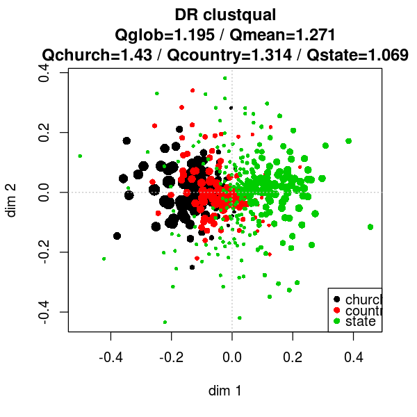

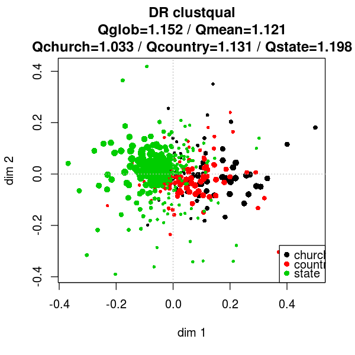

```r
dr_clouds('lemma')
```

## Silhouette based

General measure

```r
sil_tokvecs <- function(clusterclass){
    semvar6<-clusterqualSIL(tokvecs6, d6[,clusterclass])
    semvar10<-clusterqualSIL(tokvecs10, d10[,clusterclass])
    make_col <- function(semvardf, df_name){
        freqs <- as.vector(semvardf$classfreqs)
        n <- c(sum(freqs), length(freqs), freqs)
        q <- round(c(semvardf$globqual, semvardf$meanclassqual, semvardf$classqual),3)
        d<-cbind(n, q)
        row.names(d)<-c('global separability', 'mean class separability', names(semvardf$classqual))
        colnames(d)<-c(paste0(df_name, '_n'), paste0(df_name, '_q'))
        return(d)
    }
    print(paste0('Silhouette based separability, based on ', clusterclass))
    print(cbind(make_col(semvar6, '6k'), make_col(semvar10, '10k')))
    options(repr.plot.width=5, repr.plot.height=5)
    plot(semvar6, coord6)
    plot(semvar10, coord10)
    }
```

```r
sil_clouds <- function(clusterclass){
    semvar6<-clusterqualSIL(dist6, c6[,clusterclass])
    semvar10<-clusterqualSIL(dist10, c10[,clusterclass])
    make_col <- function(semvardf, df_name){
        freqs <- as.vector(semvardf$classfreqs)
        n <- c(sum(freqs), length(freqs), freqs)
        q <- round(c(semvardf$globqual, semvardf$meanclassqual, semvardf$classqual),3)
        d<-cbind(n, q)
        row.names(d)<-c('global separability', 'mean class separability', names(semvardf$classqual))
        colnames(d)<-c(paste0(df_name, '_n'), paste0(df_name, '_q'))
        return(d)
    }
    print(paste0('Silhouette based separability, based on ', clusterclass))
    print(cbind(make_col(semvar6, '6k'), make_col(semvar10, '10k')))
    options(repr.plot.width=5, repr.plot.height=5)
    plot(semvar6, coord6)
    plot(semvar10, coord10)
    }
```

```
                        6k_n   6k_q 10k_n  10k_q
global separability      499  0.010   499  0.011
mean class separability    3  0.017     3  0.004
church                    95  0.018    93 -0.016
country                  115  0.038   114  0.008
state                    289 -0.004   292  0.021
```

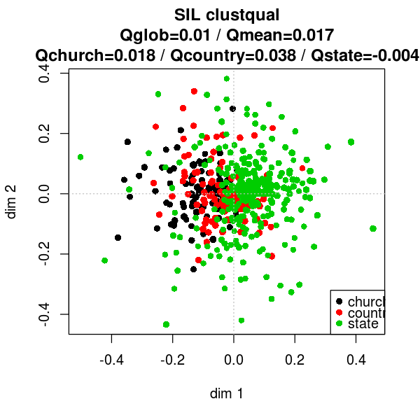

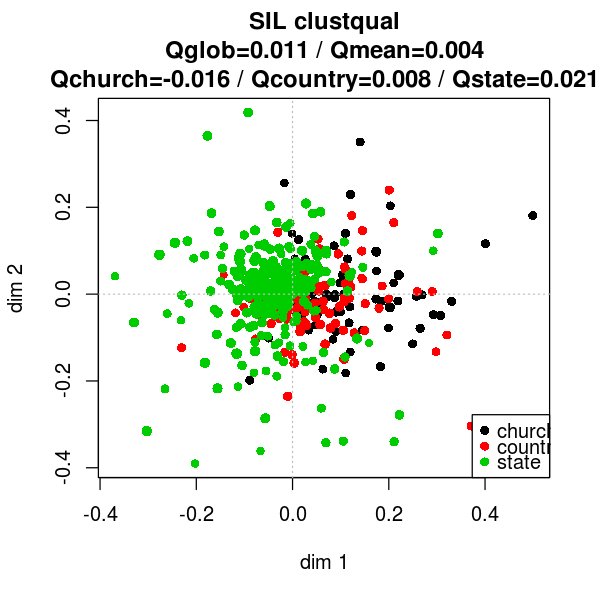

```r
sil_tokvecs('lemma')
```

```
                        6k_n   6k_q 10k_n  10k_q
global separability      497 -0.011   493  0.023
mean class separability    3  0.012     3 -0.011
church                    95  0.042    93 -0.106
country                  115  0.046   114 -0.004
state                    287 -0.052   286  0.076
```

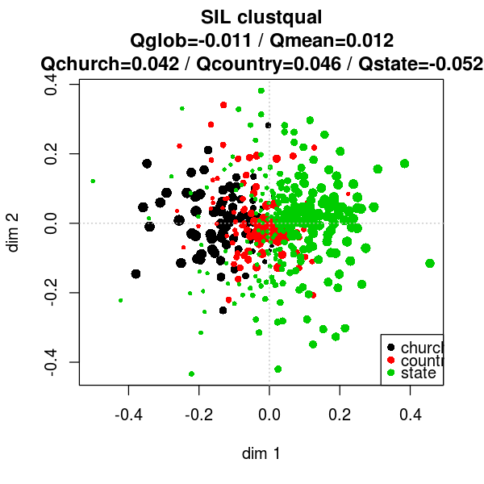

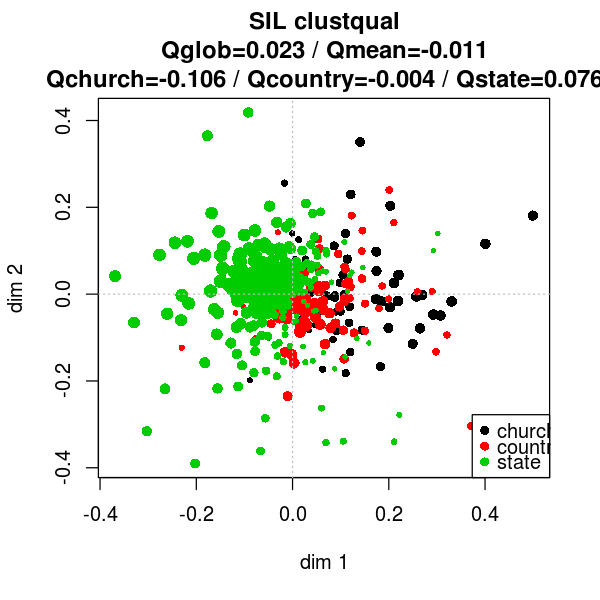

```r
sil_clouds('lemma')
```

## Same Class Paths based

Local measure

```r
scp_tokvecs <- function(clusterclass, k=NULL, b=FALSE){
    semvar6<-clusterqualSCP(tokvecs6, d6[,clusterclass], k=k, backtracking=b)
    semvar10<-clusterqualSCP(tokvecs10, d10[,clusterclass], k=k, backtracking=b)
    make_col <- function(semvardf, df_name){
        freqs <- as.vector(semvardf$classfreqs)
        n <- c(sum(freqs), length(freqs), freqs)
        q <- round(c(semvardf$globqual, semvardf$meanclassqual, semvardf$classqual),3)
        d<-cbind(n, q)
        row.names(d)<-c('global separability', 'mean class separability', names(semvardf$classqual))
        colnames(d)<-c(paste0(df_name, '_n'), paste0(df_name, '_q'))
        return(d)
    }
    cat(paste0('Same Class Paths based separability, based on ', clusterclass), '\n')
    cat(paste0('k: ', semvar6$k, '; Backtracking: ', semvar6$backtracking, '\n'))
    print(cbind(make_col(semvar6, '6k'), make_col(semvar10, '10k')))
    options(repr.plot.width=5, repr.plot.height=5)
    plot(semvar6, coord6)
    plot(semvar10, coord10)
    }
```

```r
scp_clouds <- function(clusterclass, k=NULL, b=FALSE){
    semvar6<-clusterqualSCP(dist6, c6[,clusterclass], k=k, backtracking=b)
    semvar10<-clusterqualSCP(dist10, c10[,clusterclass], k=k, backtracking=b)
    make_col <- function(semvardf, df_name){
        freqs <- as.vector(semvardf$classfreqs)
        n <- c(sum(freqs), length(freqs), freqs)
        q <- round(c(semvardf$globqual, semvardf$meanclassqual, semvardf$classqual),3)
        d<-cbind(n, q)
        row.names(d)<-c('global separability', 'mean class separability', names(semvardf$classqual))
        colnames(d)<-c(paste0(df_name, '_n'), paste0(df_name, '_q'))
        return(d)
    }
    cat(paste0('Same Class Paths based separability, based on ', clusterclass), '\n')
    cat(paste0('k: ', semvar6$k, '; Backtracking: ', semvar6$backtracking, '\n'))
    print(cbind(make_col(semvar6, '6k'), make_col(semvar10, '10k')))
    options(repr.plot.width=5, repr.plot.height=5)
    plot(semvar6, coord6)
    plot(semvar10, coord10)
    }
```

```r
help(clusterqualSCP)
```

```
Same Class Paths based separability, based on lemma
k: 50; Backtracking: 1
                        6k_n  6k_q 10k_n 10k_q
global separability      499 0.704   499 0.526
mean class separability    3 0.590     3 0.364
church                    95 0.445    93 0.128
country                  115 0.427   114 0.174
state                    289 0.899   292 0.791
```

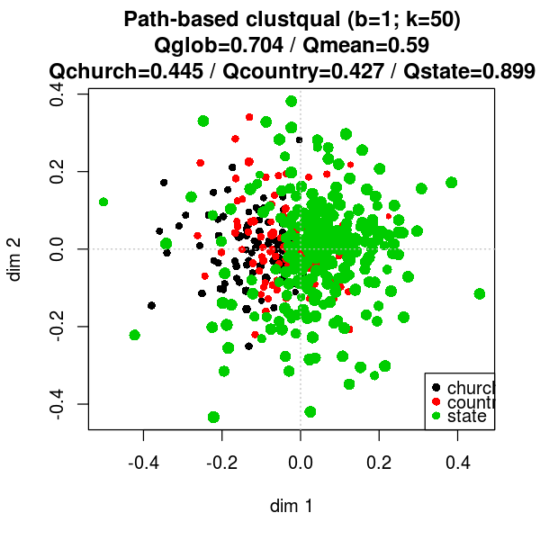

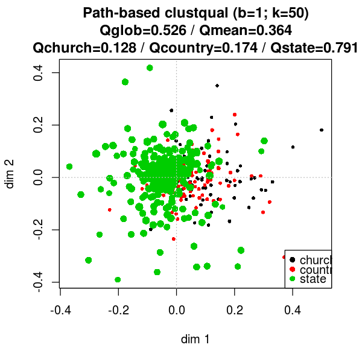

```r
scp_tokvecs('lemma')
```

```
Same Class Paths based separability, based on lemma
k: 50; Backtracking: 1
                        6k_n  6k_q 10k_n 10k_q
global separability      497 0.467   493 0.406
mean class separability    3 0.387     3 0.302
church                    95 0.228    93 0.152
country                  115 0.333   114 0.173
state                    287 0.600   286 0.582
```

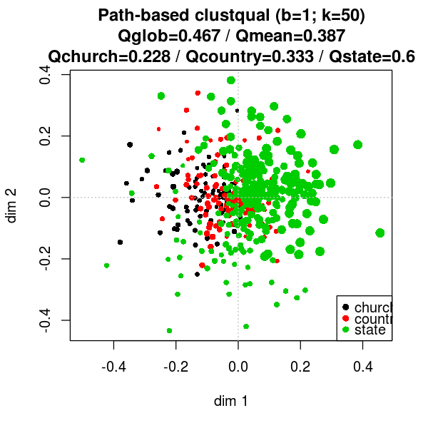

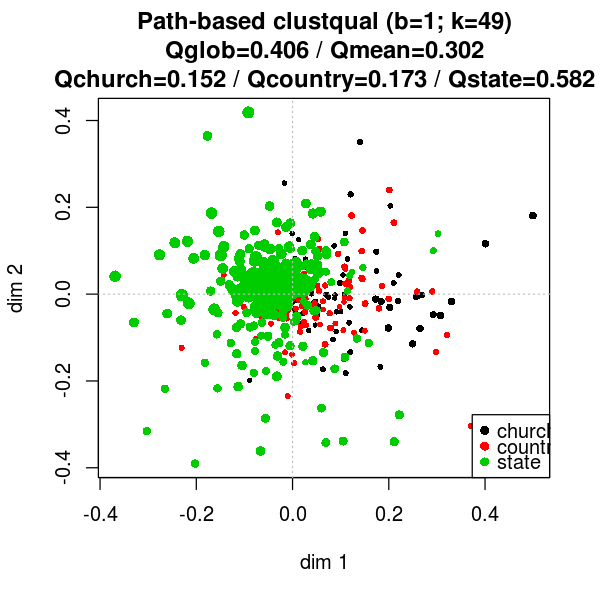

```r
scp_clouds('lemma')
```

```
Same Class Paths based separability, based on newBroadGenre
k: 42; Backtracking: 1
                        6k_n  6k_q 10k_n 10k_q
global separability      499 0.831   499 0.885
mean class separability    2 0.463     2 0.497
imaginative               43 0.019    50 0.011
informative              456 0.908   449 0.983
```

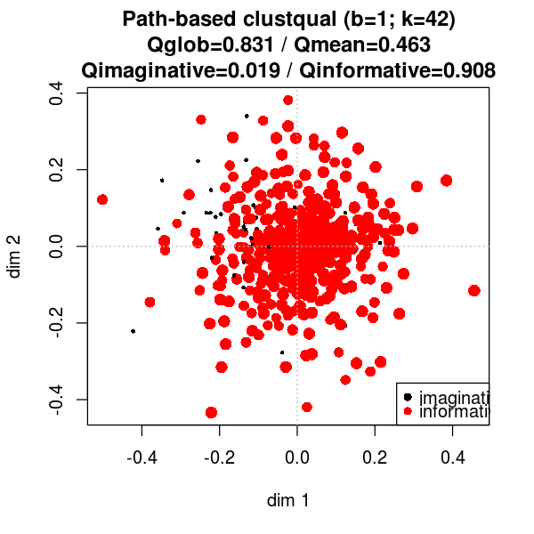

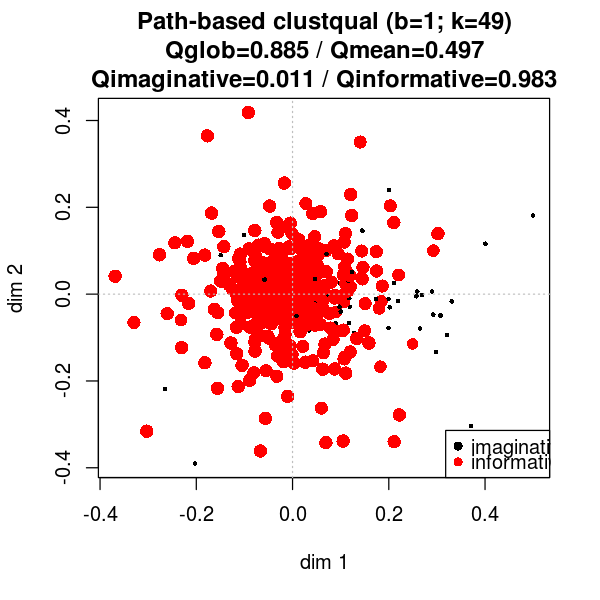

```r
scp_tokvecs('newBroadGenre')
```

```
Same Class Paths based separability, based on newBroadGenre
k: 41; Backtracking: 1
                        6k_n  6k_q 10k_n 10k_q
global separability      497 0.833   493 0.853
mean class separability    2 0.477     2 0.500
imaginative               42 0.048    49 0.060
informative              455 0.906   444 0.940
```

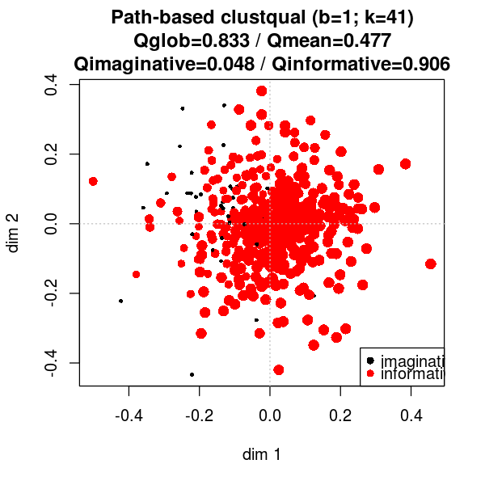

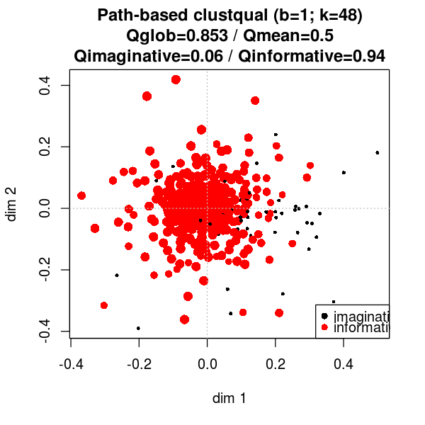

```r
scp_clouds('newBroadGenre')
```

```
Same Class Paths based separability, based on newBroadGenre
k: 15; Backtracking: 1
                        6k_n  6k_q 10k_n 10k_q
global separability      499 0.831   499 0.885
mean class separability    2 0.536     2 0.508
imaginative               43 0.179    50 0.037
informative              456 0.892   449 0.979
```

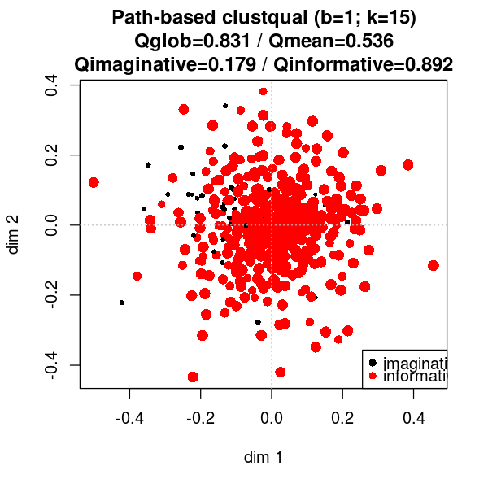

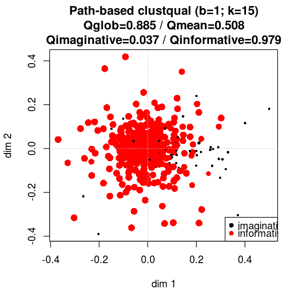

```r
scp_tokvecs('newBroadGenre', k=15)
```

```
Same Class Paths based separability, based on newBroadGenre
k: 15; Backtracking: 1
                        6k_n  6k_q 10k_n 10k_q
global separability      497 0.853   493 0.877
mean class separability    2 0.529     2 0.634
imaginative               42 0.140    49 0.332
informative              455 0.919   444 0.937
```

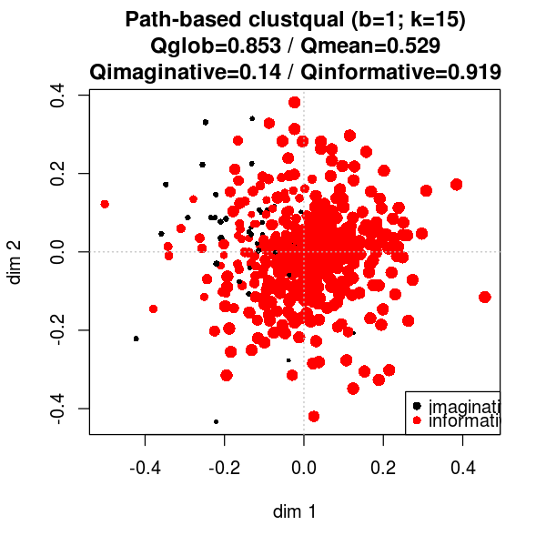

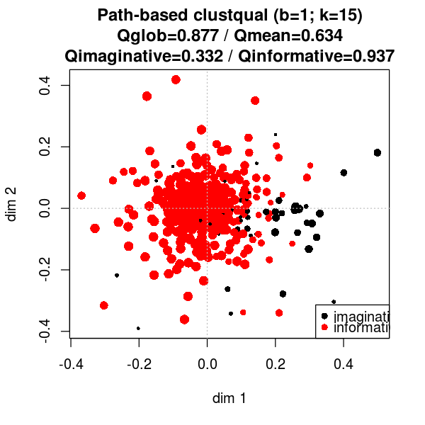

```r
scp_clouds('newBroadGenre', k=15)
```

```
Same Class Paths based separability, based on newBroadGenre
k: 10; Backtracking: 1
                        6k_n  6k_q 10k_n 10k_q
global separability      499 0.837   499 0.892
mean class separability    2 0.547     2 0.545
imaginative               43 0.197    50 0.111
informative              456 0.897   449 0.979
```

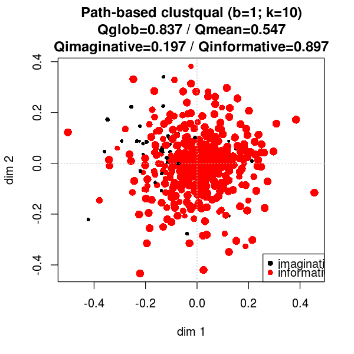

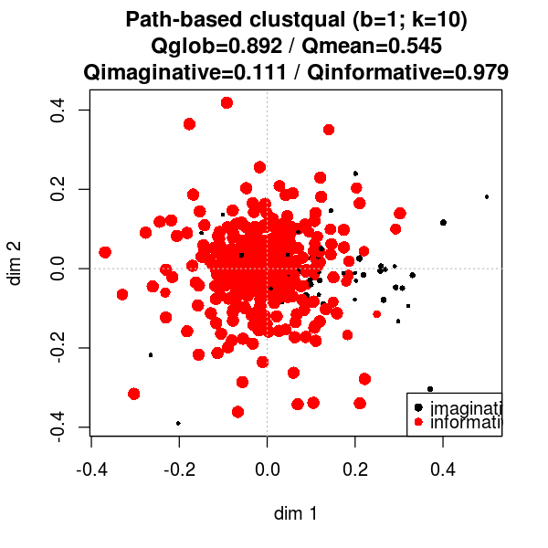

```r
scp_tokvecs('newBroadGenre', k=10)
```

```
Same Class Paths based separability, based on newBroadGenre
k: 10; Backtracking: 1
                        6k_n  6k_q 10k_n 10k_q
global separability      497 0.862   493 0.878
mean class separability    2 0.551     2 0.646
imaginative               42 0.177    49 0.355
informative              455 0.925   444 0.936
```

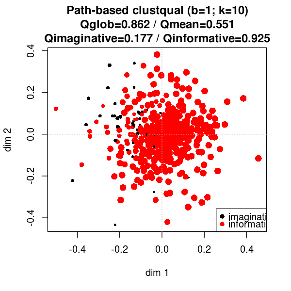

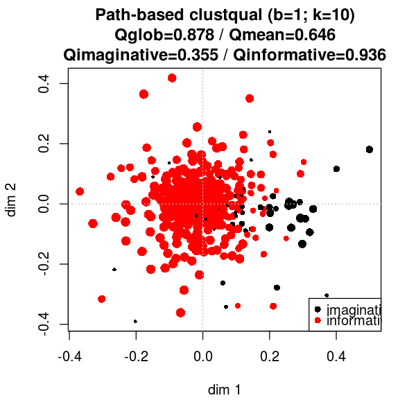

```r
scp_clouds('newBroadGenre', k=10)
```

```
Same Class Paths based separability, based on newBroadGenre
k: 15; Backtracking: 2
                        6k_n  6k_q 10k_n 10k_q
global separability      499 0.874   499 0.900
mean class separability    2 0.594     2 0.577
imaginative               43 0.256    50 0.172
informative              456 0.933   449 0.981
```

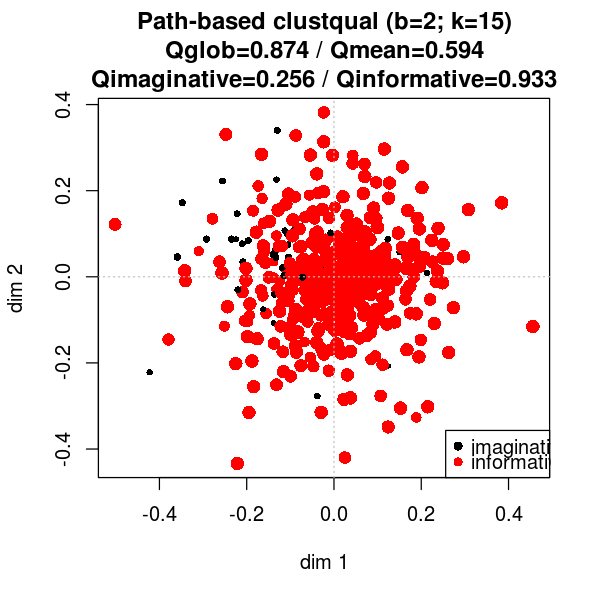

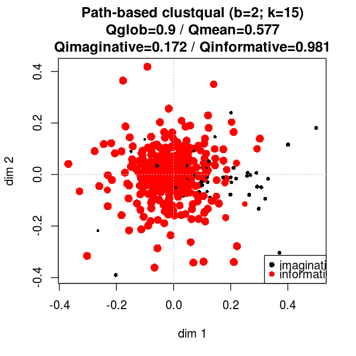

```r
scp_tokvecs('newBroadGenre', k=15, b=2)
```

```
Same Class Paths based separability, based on newBroadGenre
k: 15; Backtracking: 2
                        6k_n  6k_q 10k_n 10k_q
global separability      497 0.881   493 0.898
mean class separability    2 0.578     2 0.682
imaginative               42 0.214    49 0.413
informative              455 0.942   444 0.951
```

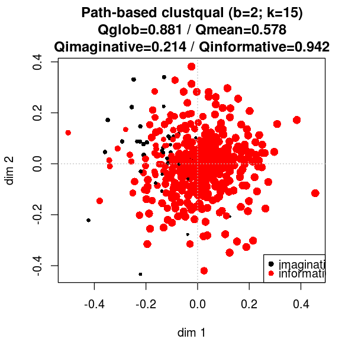

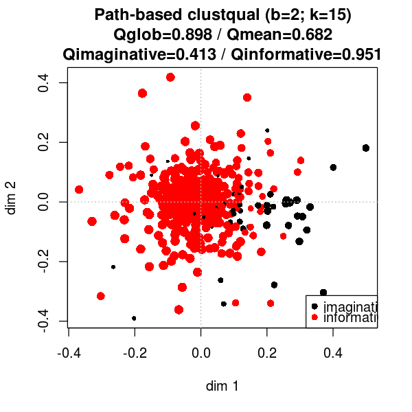

```r
scp_clouds('newBroadGenre', k=15, b=2)
```

```
Same Class Paths based separability, based on broadGenre
k: 42; Backtracking: 1
                        6k_n  6k_q 10k_n 10k_q
global separability      499 0.531   499 0.423
mean class separability    3 0.403     3 0.339
imag                      43 0.019    50 0.011
others                   264 0.496   285 0.376
tech                     192 0.695   164 0.630
```

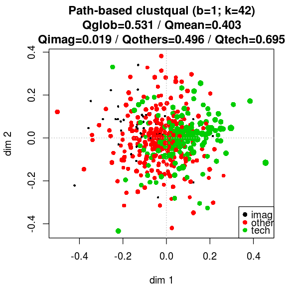

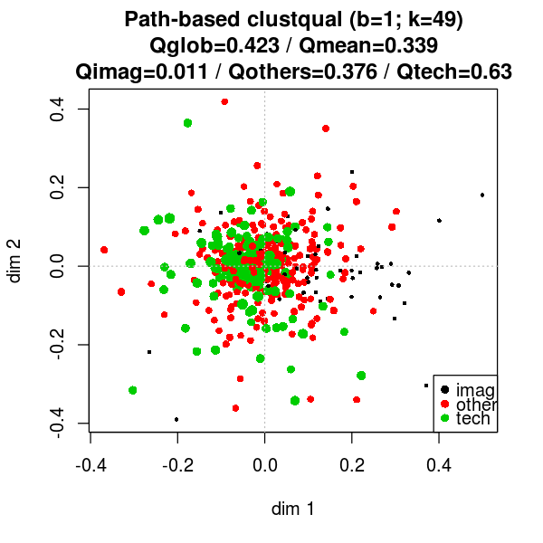

```r
scp_tokvecs('broadGenre')
```

```
Same Class Paths based separability, based on broadGenre
k: 41; Backtracking: 1
                        6k_n  6k_q 10k_n 10k_q
global separability      497 0.431   493 0.399
mean class separability    3 0.328     3 0.297
imag                      42 0.048    49 0.060
others                   264 0.461   282 0.492
tech                     191 0.475   162 0.339
```

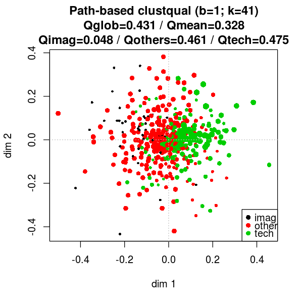

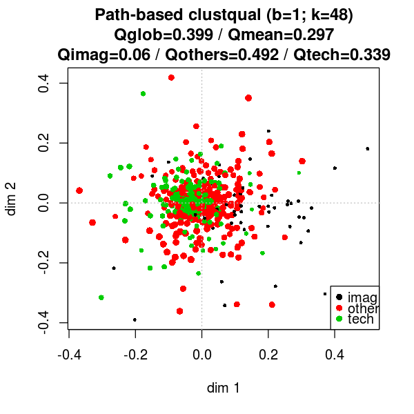

```r
scp_clouds('broadGenre')
```